# Machine Learning Course project: Predicting quality of weight lifting

Espen Svendsen

29 4 2017

# Summmary

This course project uses HAR data from Groupware@LES available at [Human Activity Recognition](http://groupware.les.inf.puc-rio.br/har). These data are collected from accelerometers on the belt, forearm, arm and dumbell of 6 participants. They were asked to perform barbell lifts correctly and incorrectly in 5 different ways:

- Class A: Exactly according to the specification
- Class B: Throwing the elbows to the front
- Class C: Lifting the dumbbell only halfway
- Class D: Lowering the dumbbell only halfway
- Class E. Throwing the hips to the front

By applying various machine learning algorithms and parameters on this data set, the conclusion is that Random Forest yielded the best predictions of the attempted algorithms. The prediction accuracy exceeded 99% for out-of-sample data.

# Pre-processing

The data is downloaded prior to pre-processing.

Dimensions of full data set and quiz set are:

```r
dim(dataSet)
```

```
## [1] 19622   160
```

```r
dim(quiz)
```

```
## [1]  20 160
```

The “quiz” set (“testing.csv”) is not intended for testing as we normally define this term in machine learning. Rather, we use the full “dataSet” to split into a training and a testing set. The size of the dataset is fairly large, so we set the training set to 3/4 of the total.

```r
set.seed(1)
inTrain = createDataPartition(dataSet$classe, p = 3/4)[[1]]
training = dataSet[ inTrain,]
testing = dataSet[-inTrain,]
rm(dataSet) # not required anymore, may be freed from memory
```

### Data cleansing

The data cleansing assessments are described in-line in the following code section.

```r
# Removing subject and time/windowing
# These are variables that will not occur in new observations, hence they will lead to overfitting if included.
training <- training[,-c(1:7)]
testing <- testing[,-c(1:7)]

# Removing useless features
sumNA <- sapply(training, function(x) sum(is.na(x)))
# table(sumNA)
##  0 14408
## 86    67  => The 67 columns with high number of NAs may be removed
training <- training[, sumNA == 0]
testing <- testing[, sumNA == 0]

# Removing constant features
nzv <- nearZeroVar(training, saveMetrics = TRUE)
training <- training[, !(nzv$zeroVar + nzv$nzv > 0)]
testing <- testing[, !(nzv$zeroVar + nzv$nzv > 0)]
```

Some further cleansing steps were considered and disregarded:

- As the outcome variable “classe” is a multiclass variable, linear models are normally not suited. Therefore, normalization is not attempted.
- Highly correlated features might have been removed, but this is normally most important for linear models. Although not shown here, removing highly correlated features yielded a slightly WORSE performance.

## Model building

Several models has been attempted, and the final model build by a Random Forest algorithm is shown here. The model has been built with cross-validation to minimize model bias.

The resulted model is:

```r
modelRF
```

```
## Random Forest
##
## 14718 samples
##    52 predictor
##     5 classes: 'A', 'B', 'C', 'D', 'E'
##
## No pre-processing
## Resampling: Cross-Validated (4 fold)
## Summary of sample sizes: 11039, 11038, 11038, 11039
## Resampling results across tuning parameters:
##
##   mtry  Accuracy   Kappa
##    2    0.9908277  0.9883966
##   27    0.9913710  0.9890843
##   52    0.9856635  0.9818641
##
## Accuracy was used to select the optimal model using  the largest value.
## The final value used for the model was mtry = 27.
```

### Out-of-sample error

The more realistic performance is gained by calculating the out-of-sample accuracy over testing set.

```r
predOutOfSampleRF <- predict(modelRF, newdata = testing, interval="prediction")
confusion <- confusionMatrix(predOutOfSampleRF, testing$classe)
errorOutOfSampleRF <- 1 - confusion$overall["Accuracy"]
confusion
```

```
## Confusion Matrix and Statistics
##
##           Reference
## Prediction    A    B    C    D    E
##          A 1390    5    0    0    0
##          B    2  942    4    0    0
##          C    2    2  849    7    0
##          D    0    0    2  796    3
##          E    1    0    0    1  898
##
## Overall Statistics
##
##                Accuracy : 0.9941
##                  95% CI : (0.9915, 0.996)
##     No Information Rate : 0.2845
##     P-Value [Acc > NIR] : < 2.2e-16
##
##                   Kappa : 0.9925
##  Mcnemar's Test P-Value : NA
##
## Statistics by Class:
##
##                      Class: A Class: B Class: C Class: D Class: E
## Sensitivity            0.9964   0.9926   0.9930   0.9900   0.9967
## Specificity            0.9986   0.9985   0.9973   0.9988   0.9995
## Pos Pred Value         0.9964   0.9937   0.9872   0.9938   0.9978
## Neg Pred Value         0.9986   0.9982   0.9985   0.9981   0.9993
## Prevalence             0.2845   0.1935   0.1743   0.1639   0.1837
## Detection Rate         0.2834   0.1921   0.1731   0.1623   0.1831
## Detection Prevalence   0.2845   0.1933   0.1754   0.1633   0.1835
## Balanced Accuracy      0.9975   0.9956   0.9951   0.9944   0.9981
```

The accuracy on the testing set is 0.9940865, which is considered high. The error rate is 0.0059135. This indicates a model robust to out-of-sample data.

### Visualization

The resulted prediction results are visualized in a plotted confusion matrix.

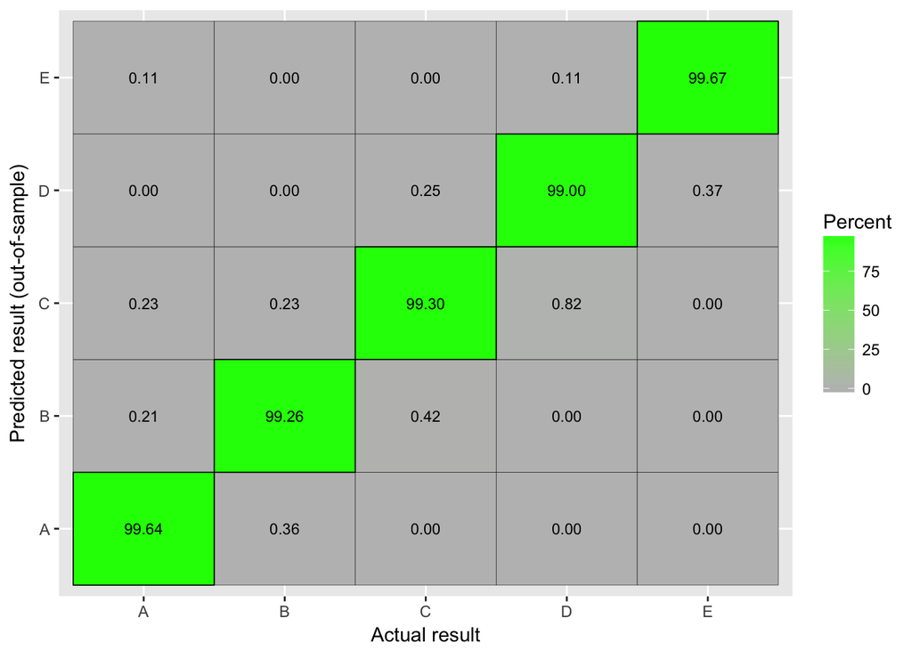

```r
# Data frames required for ggplot
actualDF = as.data.frame(table(testing$classe))
names(actualDF) = c("Actual","ActualFreq")

predictedDF <- as.data.frame(table("Predicted"=predOutOfSampleRF, "Actual"=testing$classe))
confusionDF = cbind(predictedDF, actualDF)
confusionDF$Percent = confusionDF$Freq/confusionDF$ActualFreq*100

# Tile plot
tile <- ggplot() +
  geom_tile(aes(x=Actual, y=Predicted,fill=Percent),data=confusionDF,
            color="black",size=0.1) +labs(x="Actual result", y="Predicted result (out-of-sample)")
tile = tile + geom_text(aes(x=Actual,y=Predicted,
              label=sprintf("%.2f", Percent)), data=confusionDF, size=3,
              colour="black") + scale_fill_gradient(low="grey", high="green")
tile = tile + geom_tile(aes(x=Actual, y=Predicted),
              data=subset(confusionDF, as.character(Actual)==as.character(Predicted)), color="black",size=0.3, fill="black", alpha=0)
tile
```

## Conclusion

The low out-of-sample error indicates that the final model is a good fit. The Random Forest algorithm performed with a total accuracy of 0.9940865.

## Epilogue: Prediction on quiz

Finally the quiz data is predicted by means of the Random Forest model

```r
quiz <- quiz[, c(names(training[, -ncol(training)]), "problem_id")]
predict(modelRF, newdata=quiz)
```

```
##  [1] B A B A A E D B A A B C B A E E A B B B
## Levels: A B C D E
```